# Выявление закономерностей определяющие успешность игры

Из открытых источников нам доступны исторические данные от одного из интернет-магазинов с играми о продажах игр по регионам (Северная Америка, Европа, Япония и другие страны), оценки пользователей и экспертов, жанры и платформы (например, Xbox или PlayStation). Нам нужно выявить определяющие успешность игры закономерности. Это позволит сделать ставку на потенциально популярный продукт и спланировать рекламные кампании. Перед нами данные до 2016 года. Представим, что сейчас декабрь 2016 г., и мы планируем рекламную кампанию на 2017-й. В наборе данных попадается аббревиатура ESRB (Entertainment Software Rating Board) — это ассоциация, определяющая возрастной рейтинг компьютерных игр. ESRB оценивает игровой контент и присваивает ему подходящую возрастную категорию, например, «Для взрослых», «Для детей младшего возраста» или «Для подростков».

В ходе проведения анализа данных мы узнаем, как менялись продажи по платформам, какие платформы лидируют по продажам, оценим влияние оценок пользователей и экспертов на продажи тех или иных игр, узнаем какие самые популярные игры, жанры, и платформы, а также проверим гипотезы на популярность жанров и платформ.

В целом вся проделанная нами работа позволит спланировать рекламную кампанию, и эти данные направить коллегам в маркетинговый отдел.

## Изучение данных из файла

Импортируем все необходимые библиотеки для будущей работы

```python
import pandas as pd

import matplotlib.pyplot as plt

import numpy as np

import seaborn as sns

from scipy import stats as st

import re

import warnings
warnings.filterwarnings('ignore')
```

```python
# читаем файл, и сохраняем его в переменной
try: # пытаемся подгрузить данные с платформы...
    games = pd.read_csv('/datasets/games.csv')
except: # ...в случае ошибки подгружаем данные локально
    games = pd.read_csv('c:\\games.csv')
```

```python
# смотрим на первые строки датасета
games.head()
```

|  | Name | Platform | Year_of_Release | Genre | NA_sales | EU_sales | JP_sales | Other_sales | Critic_Score | User_Score | Rating |
| --- | --- | --- | --- | --- | --- | --- | --- | --- | --- | --- | --- |
| 0 | Wii Sports | Wii | 2006.0 | Sports | 41.36 | 28.96 | 3.77 | 8.45 | 76.0 | 8 | E |
| 1 | Super Mario Bros. | NES | 1985.0 | Platform | 29.08 | 3.58 | 6.81 | 0.77 | NaN | NaN | NaN |
| 2 | Mario Kart Wii | Wii | 2008.0 | Racing | 15.68 | 12.76 | 3.79 | 3.29 | 82.0 | 8.3 | E |
| 3 | Wii Sports Resort | Wii | 2009.0 | Sports | 15.61 | 10.93 | 3.28 | 2.95 | 80.0 | 8 | E |
| 4 | Pokemon Red/Pokemon Blue | GB | 1996.0 | Role-Playing | 11.27 | 8.89 | 10.22 | 1.00 | NaN | NaN | NaN |

```python
# просматриваем общую информацию по датасету
games.info()
```

```
<class 'pandas.core.frame.DataFrame'>
RangeIndex: 16715 entries, 0 to 16714
Data columns (total 11 columns):
Name               16713 non-null object
Platform           16715 non-null object
Year_of_Release    16446 non-null float64
Genre              16713 non-null object
NA_sales           16715 non-null float64
EU_sales           16715 non-null float64
JP_sales           16715 non-null float64
Other_sales        16715 non-null float64
Critic_Score       8137 non-null float64
User_Score         10014 non-null object
Rating             9949 non-null object
dtypes: float64(6), object(5)
memory usage: 1.1+ MB
```

### Вывод

**Из выше выведенных данных мы видим, что таблица содержит 11 колонок: название игры, платформа, год выпуска, жанр, продажи в Северной Америке(млн.проданных копий), продажи в Европе(млн.проданных копий), продажи в Японии(млн.проданных копий), продажи в других странах(млн.проданных копий), оценка критиков(максимум 100), оценка пользователей(максимум 10), и рейтинг от организации ESRB, которая определяет рейтинг игр, и присваивает им подходящую возрастную категорию.**

**Проблемы, которые надо будет решать, это замена названий столбцов на нижний регистр, преобразовать данные в нужные нам типы, заменить пропуски.**

## Предобработка данных

### Обработка пропусков

```python
# заменяем название столбцов - приводим их нижнему регистру
games.columns = games.columns.str.lower()

# посмотрим, что у нас вышло
games.columns
```

```
Index(['name', 'platform', 'year_of_release', 'genre', 'na_sales', 'eu_sales',
       'jp_sales', 'other_sales', 'critic_score', 'user_score', 'rating'],
      dtype='object')
```

```python
# определим сколько и в каких столбцах у нас есть пропуски
games.isna().sum()
```

```
name                  2
platform              0
year_of_release     269
genre                 2
na_sales              0
eu_sales              0
jp_sales              0
other_sales           0
critic_score       8578
user_score         6701
rating             6766
dtype: int64
```

Далее, в столбцах с малым количеством пропусков (название игры, и жанр) удалим строки. Потом, попробуем обогатить столбец с годом выпуска игры, насколько у нас это получится, при помощи функции для регулярных выражений из столбца с названием игры вычленим год, и вставим его в местах пропуска в столбце с годом выпуска игры. Оставшиеся пропуски в строках столбца с годом выпуска игры просто удалим. В столбце с оценкой критиков сделаем замену пропусков на ноль. В столбце с пропусками оценкой пользователей также заменим на ноль. А в столбце с рейтингом от компании ESRB заменим пропуски на заглушку `Unknown`, вероятнее всего рейтинг не был присвоен. Потому как компания негосударственная и находится в Канаде и США, очевидно она не может, и не будет оценивать все игры мира.

```python
# удаляем строки в столбцах, в которых были малочисленные пропуски
games.dropna(subset=['name', 'genre'], inplace=True)
```

```python
# создаём функцию для отработки регулярных выражений по дате
def sep_year(row):
    year = re.search(r'\d{4}', row)
    if year is None:
        return np.nan
    return int(year.group(0))

# создаём временный дополнительный столбец для вывода функции регулярки
games['year_from_name'] = games['name'].apply(sep_year)

# сохраняем пропуски из сотлбца с годом выпуска в переменной
na_mask = games['year_of_release'].isnull()

# заменяем пропуски из временного столбца в столбец с годом выпуска игры
games.loc[na_mask, 'year_of_release'] = games.loc[na_mask, 'year_from_name']

# удаляем временный столбец
games.drop(['year_from_name'], axis=1, inplace=True)
```

```python
# оставшиеся строки с пропусками в столбце с годом выпуска игры удаляем
games.dropna(subset=['year_of_release'], inplace=True)
```

```python
# заполняем столбец с оценкой критиков нулями
games['critic_score'] = games['critic_score'].fillna(0)
```

Далее в столбце с оценкой пользователей встречается аббревиатура "tbd", которая в игровой индустрии зачастую расшифровывается, как "to be determinated" - подлежит определению. Ввиду того, что игры либо ещё не были выпущены, либо они ещё совсем недавно вышли, и не набрали критически массы для оценки. Потому эти значения заменим на нули.

```python
# просматриваем уникальные значения
games['user_score'].unique()
```

```
array(['8', nan, '8.3', '8.5', '6.6', '8.4', '8.6', '7.7', '6.3', '7.4',
       '8.2', '9', '7.9', '8.1', '8.7', '7.1', '3.4', '5.3', '4.8', '3.2',
       '8.9', '6.4', '7.8', '7.5', '2.6', '7.2', '9.2', '7', '7.3', '4.3',
       '7.6', '5.7', '5', '9.1', '6.5', 'tbd', '8.8', '6.9', '9.4', '6.8',
       '6.1', '6.7', '5.4', '4', '4.9', '4.5', '9.3', '6.2', '4.2', '6',
       '3.7', '4.1', '5.8', '5.6', '5.5', '4.4', '4.6', '5.9', '3.9',
       '3.1', '2.9', '5.2', '3.3', '4.7', '5.1', '3.5', '2.5', '1.9', '3',
       '2.7', '2.2', '2', '9.5', '2.1', '3.6', '2.8', '1.8', '3.8', '0',
       '1.6', '9.6', '2.4', '1.7', '1.1', '0.3', '1.5', '0.7', '1.2',
       '2.3', '0.5', '1.3', '0.2', '0.6', '1.4', '0.9', '1', '9.7'],
      dtype=object)
```

```python
# заменяем значения в столбце с оценкой пользователей 'tbd' на '0'
games['user_score'] = games['user_score'].replace('tbd', '0')
```

```python
# код, чтобы убедиться, что замена таки произошла
games['user_score'].unique()
```

```
array(['8', nan, '8.3', '8.5', '6.6', '8.4', '8.6', '7.7', '6.3', '7.4',
       '8.2', '9', '7.9', '8.1', '8.7', '7.1', '3.4', '5.3', '4.8', '3.2',
       '8.9', '6.4', '7.8', '7.5', '2.6', '7.2', '9.2', '7', '7.3', '4.3',
       '7.6', '5.7', '5', '9.1', '6.5', '0', '8.8', '6.9', '9.4', '6.8',
       '6.1', '6.7', '5.4', '4', '4.9', '4.5', '9.3', '6.2', '4.2', '6',
       '3.7', '4.1', '5.8', '5.6', '5.5', '4.4', '4.6', '5.9', '3.9',
       '3.1', '2.9', '5.2', '3.3', '4.7', '5.1', '3.5', '2.5', '1.9', '3',
       '2.7', '2.2', '2', '9.5', '2.1', '3.6', '2.8', '1.8', '3.8', '1.6',
       '9.6', '2.4', '1.7', '1.1', '0.3', '1.5', '0.7', '1.2', '2.3',
       '0.5', '1.3', '0.2', '0.6', '1.4', '0.9', '1', '9.7'], dtype=object)
```

```python
# теперь оставшиеся пропуски в столбце с оценкой пользователей заменяем на ноль
games['user_score'] = games['user_score'].fillna(0)
```

```python
# пропуски в столбце с рейтингом заменяем заглушкой
games['rating'] = games['rating'].fillna("Unknown")
```

```python
# смотрим на проделанную работу
games.isna().sum()
```

```
name               0
platform           0
year_of_release    0
genre              0
na_sales           0
eu_sales           0
jp_sales           0
other_sales        0
critic_score       0
user_score         0
rating             0
dtype: int64
```

### Замена типа данных

Далее преобразовываем типы данных в столбцах.

```python
# смотрим на типы данных до внесения замены
games.dtypes
```

```
name                object
platform            object
year_of_release    float64
genre               object
na_sales           float64
eu_sales           float64
jp_sales           float64
other_sales        float64
critic_score       float64
user_score          object
rating              object
dtype: object
```

Ниже произведём замены в столбцах с годом выпуска игры, и с оценкой критиков на целочисленные, потому что в этих столбцах как раз целые числа. В столбце с оценкой пользователей заменим тип объекта на тип данных с плавающей запятой, потому что среди оценок пользователей есть оценки с десятичными долями.

```python
# заменяем тип данных в столбце с годом выпуска игры
games['year_of_release'] = games['year_of_release'].astype('int')
```

```python
# заменяем тип данных в столбце с оценкой критиков
games['critic_score'] = games['critic_score'].astype('int')
```

```python
# заменяем тип данных в столбце с оценкой пользователей
games['user_score'] = games['user_score'].astype('float')
```

```python
# посмотрим на проделанную работу
games.dtypes
```

```
name                object
platform            object
year_of_release      int32
genre               object
na_sales           float64
eu_sales           float64
jp_sales           float64
other_sales        float64
critic_score         int32
user_score         float64
rating              object
dtype: object
```

### Cуммарные продажи во всех регионах

Ниже произведём вычисления суммарных продаж во всех регионах, и запишем их в отдельный столбец.

```python
# суммируем и записываем результат в отдельный столбец
games['full_sales'] = games[['na_sales','eu_sales','jp_sales','other_sales']].sum(axis=1)

# смотрим на результат
games.head()
```

|  | name | platform | year_of_release | genre | na_sales | eu_sales | jp_sales | other_sales | critic_score | user_score | rating | full_sales |
| --- | --- | --- | --- | --- | --- | --- | --- | --- | --- | --- | --- | --- |
| 0 | Wii Sports | Wii | 2006 | Sports | 41.36 | 28.96 | 3.77 | 8.45 | 76 | 8.0 | E | 82.54 |
| 1 | Super Mario Bros. | NES | 1985 | Platform | 29.08 | 3.58 | 6.81 | 0.77 | 0 | 0.0 | Unknown | 40.24 |
| 2 | Mario Kart Wii | Wii | 2008 | Racing | 15.68 | 12.76 | 3.79 | 3.29 | 82 | 8.3 | E | 35.52 |
| 3 | Wii Sports Resort | Wii | 2009 | Sports | 15.61 | 10.93 | 3.28 | 2.95 | 80 | 8.0 | E | 32.77 |
| 4 | Pokemon Red/Pokemon Blue | GB | 1996 | Role-Playing | 11.27 | 8.89 | 10.22 | 1.00 | 0 | 0.0 | Unknown | 31.38 |

## Исследовательский анализ данных

### Количество выпущенных игр

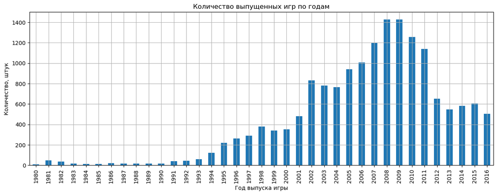

```python
# посмотрим сколько игр выпускалось в разные годы
games.groupby('year_of_release')['name'].count().plot(kind='bar',
                                                      figsize=(15, 5),
                                                      title='Количество выпущенных игр по годам',
                                                      legend=False,
                                                      grid=True)
plt.xlabel('Год выпуска игры')
plt.ylabel('Количество, штук')
plt.show()
```

Из выше преведённого графика мы видим, что рост выпуска игр был с 1990 по 2009 год. С 2010 года по 2012 происходит некоторый спад выпуска игр. После видно некоторое плато по выпуску игр. Вероятнее всего это может быть связано с развитием он-лайн игр. В целом нам для дальнейшего анализа понадобятся года с 1990 года, чтобы оценить с какой частотой возникают новые, и исчезают старые платформы.

### Анализ платформ

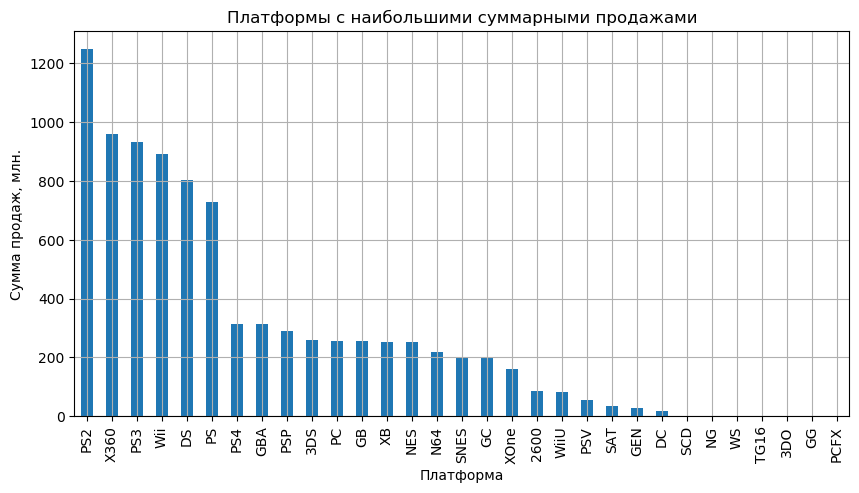

```python
# теперь взглянем на платформы с наибольшими суммарными продажами
games.groupby('platform')['full_sales'].sum().sort_values(ascending=False).plot(kind='bar',
                                                                                grid=True,
                                                                                figsize=(10, 5),
                                                                                title='Платформы с наибольшими суммарными продажами',
                                                                               )
plt.xlabel('Платформа')
plt.ylabel('Сумма продаж, млн.')
plt.show()
```

Из выше приведённого графика мы видим, что наибольшие суммарные продажи у таких платформ, как: PS2, X360, PS3, Wii, DS, PS, GBA, PS4, PSP, PC, 3DS, XB, GB, NES, N64, SNES, GC, XOne, WiiU, PSV, DC. Ниже по этим популярным платформам создадим график по годам с 1990 года.

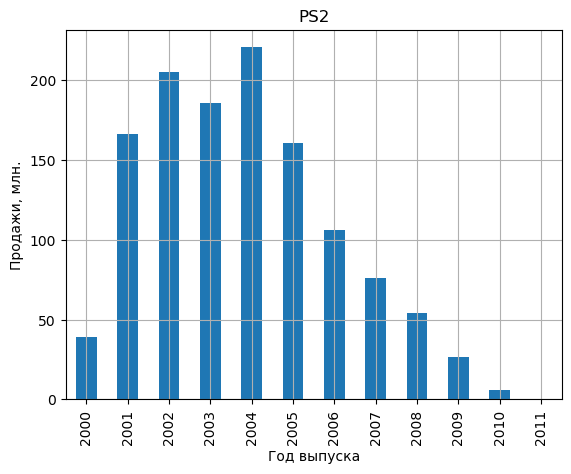

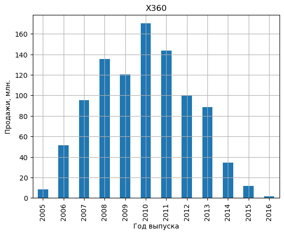

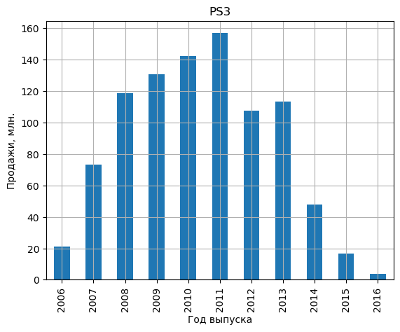

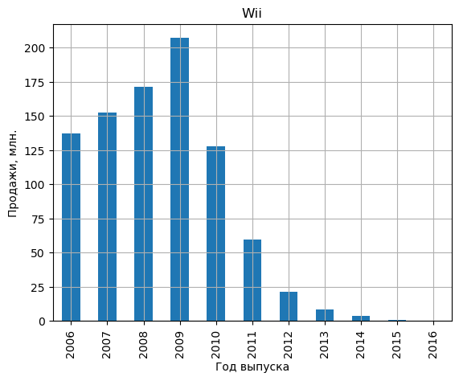

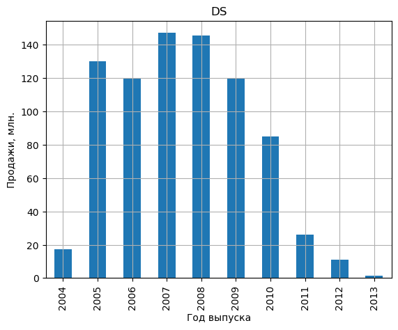

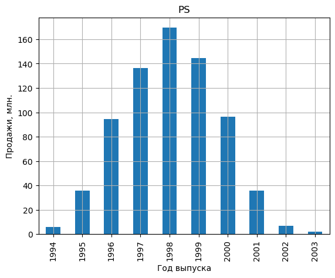

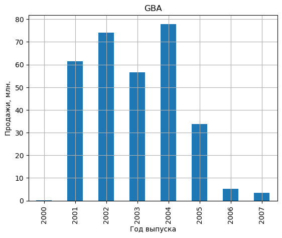

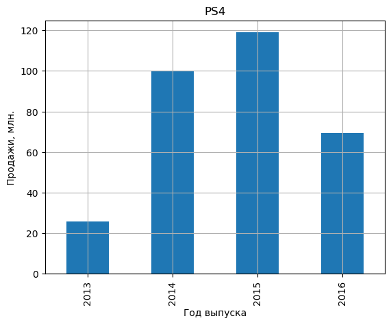

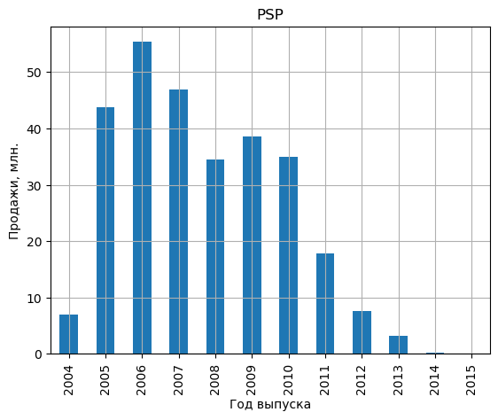

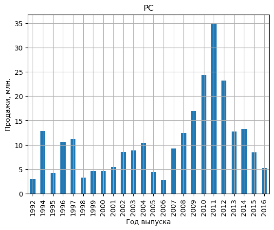

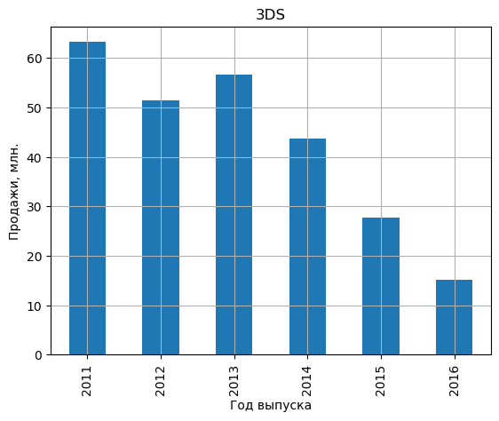

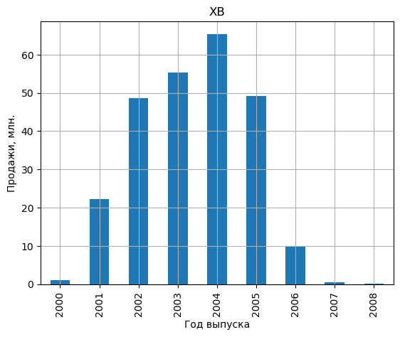

[9 more figures not shown]

```python
# строим графики продаж платформ по годам
for cur_platform in ["PS2","X360","PS3","Wii","DS","PS","GBA","PS4","PSP","PC","3DS",
                     "XB","GB","NES","N64","SNES","GC","XOne","WiiU","PSV","DC"]:
    games.query('platform == @cur_platform and year_of_release > 1990').groupby('year_of_release')['full_sales'].sum().plot(kind='bar',
                                                                                                                            title=(cur_platform),
                                                                                                                            grid=True
                                                                                                                           )
    plt.xlabel('Год выпуска')
    plt.ylabel('Продажи, млн.')
    plt.show()
```

Как мы видим из выше приведённых графиков платформ по годам, что весьма характерный срок, за который появляются новые и исчезают старые, равняется приблизительно 10 годам. Основываясь на этих выводах далее мы сделаем срез данных из датафрейма `games` по столбцу с датой выпуска игр от 2012 года, и по наиболее перспективным платформам на наш взгляд такими, как: PS4, PC, 3DS, XOne, WiiU, PSV. Ниже для этих платформ построим диаграмму размаха, которая поможет нам оценить распределение значений по прибыли, и выбрать наиболее перспективные платформы для нашей будущей рекламной кампании.

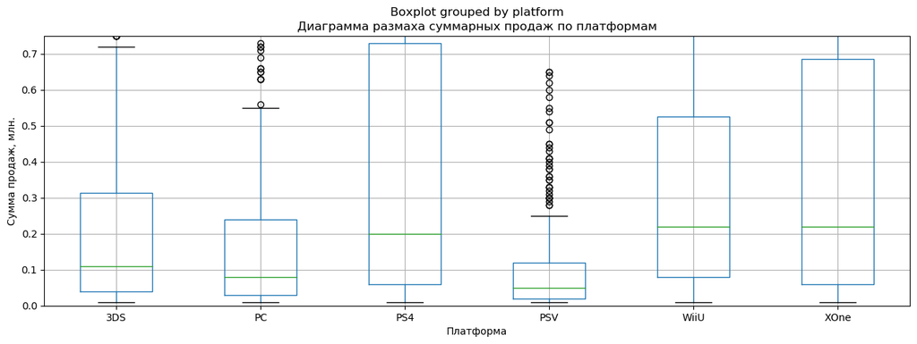

```python
# делаем срез наиболее перспективных платформ и наиболее свежие данные по выпускам игр
cur_platform = games.query( 'platform == ["PS4", "PC", "3DS", "XOne", "WiiU", "PSV"] and year_of_release >= 2012' )

# создаём диаграмму размаха
cur_platform.boxplot(column='full_sales', by='platform', figsize=(15,5))

plt.title('Диаграмма размаха суммарных продаж по платформам')
plt.xlabel('Платформа')
plt.ylabel('Сумма продаж, млн.')
plt.ylim(0, 0.75)
plt.show()
```

Из диаграммы размаха, мы видим, что по первым квартилям, медианам, и третьим квартилям наиболее перспективные для будущей нашей рекламной кампании такие платформы, как: PS4, WiiU, и XOne. Так как они приносят наибольшую прибыль, что опять-таки видно из диаграммы размаха.

### Влияние оценок пользователей и критиков

Ниже разберём каким образом влияют на продажи по платформам оценки пользователей и критиков по наиболее перспективным для нашей будущей кампании. И начнём мы с самой продаваемой платформы, и, как мы выяснили выше, наиболее перспективной - PS4.

```python
# делаем срез по платформе PS4
ps4 = cur_platform.query('platform == "PS4" and critic_score > 0 and user_score > 0' )
```

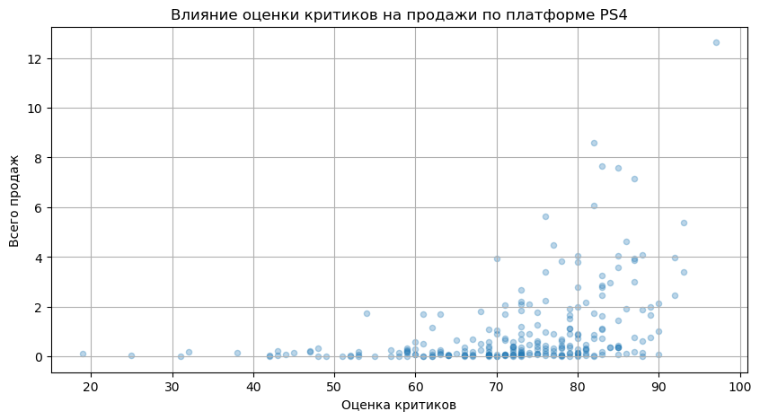

```python
# строим диаграмму рассеяния зависимости продаж от оценки критиков
ps4.plot(kind='scatter',
         x='critic_score',
         y='full_sales',
         grid=True,
         figsize=(10,5),
         alpha=0.3,
         title='Влияние оценки критиков на продажи по платформе PS4',
        )
plt.xlabel('Оценка критиков')
plt.ylabel('Всего продаж')
plt.show()
```

```python
# выводим корреляцию между оценкой критиков и продажами
ps4['critic_score'].corr(ps4['full_sales'])
```

```
0.4058948014583662
```

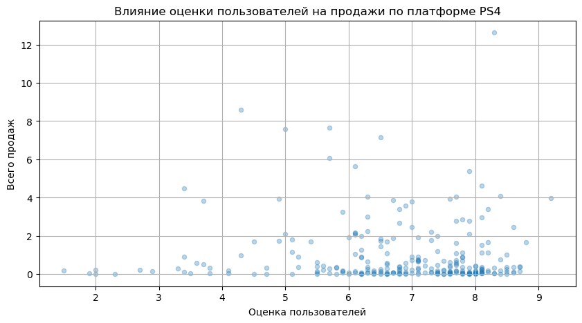

```python
# строим диаграмму рессеяния зависимости продаж от оценки пользователей
ps4.plot(kind='scatter',
         x='user_score',
         y='full_sales',
         grid=True,
         figsize=(10,5),
         alpha=0.3,
         title='Влияние оценки пользователей на продажи по платформе PS4',
        )
plt.xlabel('Оценка пользователей')
plt.ylabel('Всего продаж')
plt.show()
```

```python
# выводим корреляцию оценки пользователей и продаж
ps4['user_score'].corr(ps4['full_sales'])
```

```
-0.03362497596528883
```

Из выше выведенных графиков и корелляции оценки критиками и пользователями мы видим, что оценка критиков больше влияет на продажи игр по платформе PS4. Мы видим, что в рамках хорошо оценённых критиками (от 80-ти и выше баллов) совершается больше покупок. По графику оценки пользователей, и, в особенности, по корреляции оценки пользователей и суммарными продажами, мы видим отрицательную корреляцию. А это значит, что продажи игр фактически не зависят от оценок пользователей.

Следующая по очереди платформа для анализа - WiiU

```python
# делаем срез по платформе WiiU
wiiu = cur_platform.query('platform == "WiiU" and critic_score > 0 and user_score > 0')
```

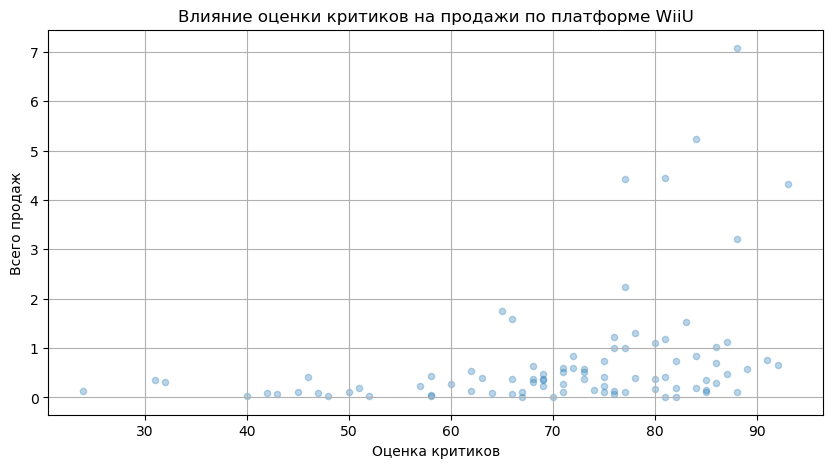

```python
# строим диаграмму рассеяния
wiiu.plot(kind='scatter',
         x='critic_score',
         y='full_sales',
         grid=True,
         figsize=(10,5),
         alpha=0.3,
         title='Влияние оценки критиков на продажи по платформе WiiU',
        )
plt.xlabel('Оценка критиков')
plt.ylabel('Всего продаж')
plt.show()
```

```python
# выводим корреляцию между оценкой критиков и продажами
wiiu['critic_score'].corr(wiiu['full_sales'])
```

```
0.35088242248864276
```

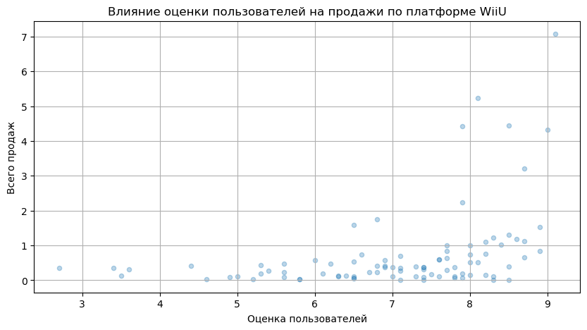

```python
# строим диграмму рессеяния зависимости продаж от оценки пользователей
wiiu.plot(kind='scatter',
         x='user_score',
         y='full_sales',
         grid=True,
         figsize=(10,5),
         alpha=0.3,
         title='Влияние оценки пользователей на продажи по платформе WiiU',
        )
plt.xlabel('Оценка пользователей')
plt.ylabel('Всего продаж')
plt.show()
```

```python
# выводим корреляцию между продажами и оценкой пользователей
wiiu['user_score'].corr(wiiu['full_sales'])
```

```
0.39184795052971266
```

Из выше выведенных графиков и корелляции оценки критиками и пользователями мы видим, что взаимосвязь между продажами и оценкой существует. При чём то, что корреляция оценок, как критиков, так и пользователей, оказывает приблизительно одинаковое влияние на продажи.

И на последок проведём анализ зависимостей продаж от оценок критиками и пользователями по платформе XOne.

```python
# делаем срез по платформе XOne
xone = cur_platform.query('platform == "XOne" and critic_score > 0 and user_score > 0')
```

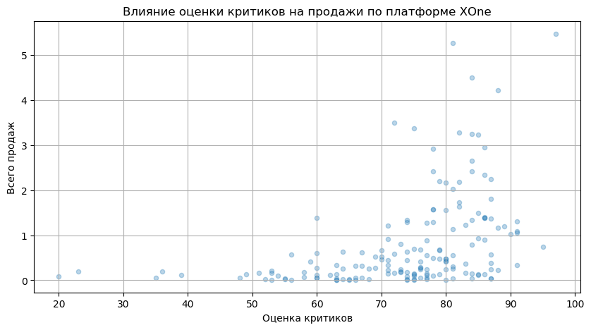

```python
# строим корреляцию зависимости продаж от оценки критиков
xone.plot(kind='scatter',
         x='critic_score',
         y='full_sales',
         grid=True,
         figsize=(10,5),
         alpha=0.3,
         title='Влияние оценки критиков на продажи по платформе XOne',
        )
plt.xlabel('Оценка критиков')
plt.ylabel('Всего продаж')
plt.show()
```

```python
# выводим корреляцию между продажами и оценкой критиков
xone['critic_score'].corr(xone['full_sales'])
```

```
0.4104220356129637
```

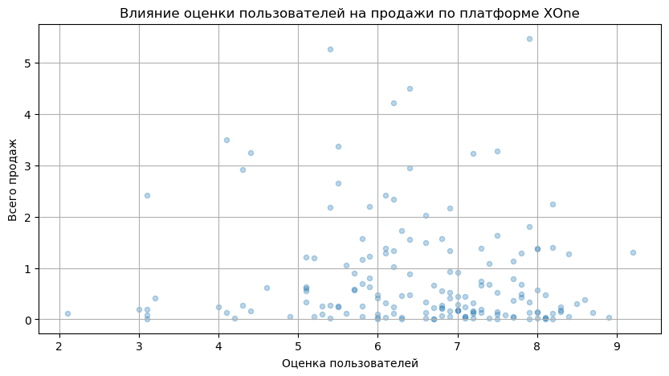

```python
# строим диаграмму рассеяния зависимости продаж от оценки пользователей
xone.plot(kind='scatter',
         x='user_score',
         y='full_sales',
         grid=True,
         figsize=(10,5),
         alpha=0.3,
         title='Влияние оценки пользователей на продажи по платформе XOne',
        )
plt.xlabel('Оценка пользователей')
plt.ylabel('Всего продаж')
plt.show()
```

```python
# выводим корреляцию продаж от оценки пользователей
xone['user_score'].corr(xone['full_sales'])
```

```
-0.09400318326920863
```

Из выше выведенных графиков и корелляции оценки критиками и пользователями мы видим, что более выраженная взаимосвязь есть от оценки критиков. При хороших оценках (от 80-ти и выше) доля продаж больше. По графику оценок пользователей и суммарными продажами, а также по корреляции между теми же значениями мы видим, что корреляция отрицательная, а значит пользовательские оценки фактически не оказываются никакого влияния на продажи игр.

Теперь посмотрим какие жанры наиболее прибыльные среди наиболее перспективных платформ.

```python
# смотрим на прибыльность игр по жанрам высчитывая относительную величину
genre = cur_platform.groupby('genre').agg({'name' : 'count', 'full_sales': 'sum'})
genre['ratio'] = genre['full_sales'] / genre['name']
genre.sort_values('ratio' , ascending = False, inplace = True)

genre
```

| genre | name | full_sales | ratio |
| --- | --- | --- | --- |
| Shooter | 136 | 171.64 | 1.262059 |
| Platform | 64 | 51.66 | 0.807188 |
| Sports | 142 | 96.21 | 0.677535 |
| Role-Playing | 262 | 147.43 | 0.562710 |
| Simulation | 57 | 31.32 | 0.549474 |
| Fighting | 56 | 28.16 | 0.502857 |
| Racing | 72 | 33.52 | 0.465556 |
| Action | 661 | 227.79 | 0.344614 |
| Misc | 129 | 42.58 | 0.330078 |
| Puzzle | 22 | 4.09 | 0.185909 |
| Strategy | 56 | 9.89 | 0.176607 |
| Adventure | 187 | 18.15 | 0.097059 |

Из выведенных выше значений мы видим, что наиболее продаваемый жанр игр, относительно выпущенных релизов и суммы продаж, это шутеры. После, соответственно, идут: платформенные, спортивные, ролевые игры, симуляции, драки/сражения, гонки, экшин игры, и т.д.

## Портрет пользователя по регионам

Ниже попробуем составить портрет потенциального пользователя по регионам. Попытаемся узнать топ-5 популярных платорм, и топ-5 жанров. А также влияет ли рейтинг компании ESRB на продажи. И начнём с самого крупного по продажам региону Северной Америки, потом по региону Европы, и после по региону Япония.

### Топ-5 платформ

```python
# сохраняем в переменной сводную таблицу топ-5 продаваемых платформ в Северной Америке
top_platforms_na = cur_platform.pivot_table(index='platform', values='na_sales', aggfunc='sum').sort_values(by='na_sales', ascending=False).head(5)

# выводим на экран
top_platforms_na
```

| platform | na_sales |
| --- | --- |
| PS4 | 108.74 |
| XOne | 93.12 |
| 3DS | 55.31 |
| WiiU | 38.10 |
| PC | 19.18 |

```python
# сохраняем в переменной сводную таблицу топ-5 продаваемых платформ в Европе
top_platforms_eu = cur_platform.pivot_table(index='platform', values='eu_sales', aggfunc='sum').sort_values(by='eu_sales', ascending=False).head(5)

# выводим на экран
top_platforms_eu
```

| platform | eu_sales |
| --- | --- |
| PS4 | 141.09 |
| XOne | 51.59 |
| 3DS | 42.64 |
| PC | 38.01 |
| WiiU | 25.13 |

```python
# сохраняем в переменной сводную таблицу топ-5 продаваемых платформ в Японии
top_platforms_jp = cur_platform.pivot_table(index='platform', values='jp_sales', aggfunc='sum').sort_values(by='jp_sales', ascending=False).head(5)

# выводим на экран
top_platforms_jp
```

| platform | jp_sales |
| --- | --- |
| 3DS | 87.79 |
| PSV | 21.04 |
| PS4 | 15.96 |
| WiiU | 13.01 |
| XOne | 0.34 |

**Вывод**

**Из выведенных выше сводных таблиц мы видим, что показатели по продажам между Северной Америкой и Европой показывают фактически одинаковую популярность тройки платформ: PS4, XOne, и 3DS. А платформа PC уступает по проадажам в Северной Америке платформе WiiU.**

**Также заметно характное отличие в популярности платформ в Японии. Там тройка более популярных платформ состоит из: 3DS, PSV, и PS4. Платформа WiiU занимает 4-е место также, как и в Северной Америке. И наконец платформа XOne, которая в Северной Америке и в Европе занимает 2-ое место по популярности, в Японии занимает лишь 5-ое место.**

### Топ-5 жанров

Выше мы узнавали самые популярные платформы в том или ином регионе. Теперь пришла очередь какие же топ-5 жанров в тех же регионах Северной Америки, Европы, и Японии.

```python
# сохраняем в переменную топ-5 жанров в Северной Америке
top_genre_na = games.pivot_table(index='genre', values='na_sales', aggfunc='sum').sort_values(by='na_sales', ascending=False).head(5)

# выводим на экран
top_genre_na
```

| genre | na_sales |
| --- | --- |
| Action | 863.23 |
| Sports | 677.65 |
| Shooter | 584.83 |
| Platform | 444.44 |
| Misc | 399.57 |

```python
# сохраняем в переменную топ-5 жанров в Европе
top_genre_eu = games.pivot_table(index='genre', values='eu_sales', aggfunc='sum').sort_values(by='eu_sales', ascending=False).head(5)

# выводим на экран
top_genre_eu
```

| genre | eu_sales |
| --- | --- |
| Action | 511.24 |
| Sports | 374.71 |
| Shooter | 314.52 |
| Racing | 234.99 |
| Misc | 210.60 |

```python
# сохраняем в переменную топ-5 жанров в Японии
top_genre_jp = cur_platform.pivot_table(index='genre', values='jp_sales', aggfunc='sum').sort_values(by='jp_sales', ascending=False).head(5)

# выводим на экран
top_genre_jp
```

| genre | jp_sales |
| --- | --- |
| Role-Playing | 51.06 |
| Action | 34.26 |
| Misc | 10.53 |
| Simulation | 9.61 |
| Platform | 8.55 |

**Вывод**

**Жанры по популярности снова показывают практически такую же картину между Северной Америкой и Европой. 1-ое место и там, и там занимают экшин игры, 2-ое место спортивные, 3-е место шутеры, и 5-ое место игры в жанре Misc. Когда 4-е место в Северной Америке занимают платформенные игры, а в Европе гонки.**

**Япония же и тут показывает свою уникальность. 1-ое место занимает жанр ролевых игр, 2-ое экшин, 3-е Misc, 4-е симуляции, и наконец 5-е платформенные.**

**Очевидно, что различия в популярности платформ и жанров между Северной Америкой, Европой и Японией сказываются культурные отличия.**

### Влияние рейтинга компании ESRB

Ниже попытаемся оценить влияние рейтинга компании ESRB на продажи игр в регионах Северной Америки, Европы, и Японии.

```python
# делаем срез игр по первоначальному датасету
games = games.query('year_of_release >= 2012')
```

```python
# делаем сводную таблицу продаж по рейтингу в Северной Америке
games.pivot_table(index='rating',
                  values='na_sales',
                  aggfunc='sum').sort_values(by='na_sales', ascending=False)
```

| rating | na_sales |
| --- | --- |
| M | 231.63 |
| E | 114.37 |
| Unknown | 103.31 |
| E10+ | 75.70 |
| T | 66.02 |

```python
# делаем сводную таблицу продаж по рейтиннгу в Европе
games.pivot_table(index='rating',
                         values='eu_sales',
                         aggfunc='sum').sort_values(by='eu_sales', ascending=False)
```

| rating | eu_sales |
| --- | --- |
| M | 194.21 |
| E | 113.03 |
| Unknown | 91.50 |
| E10+ | 55.37 |
| T | 52.96 |

```python
# делаем сводную таблицу продаж по рейтингу в Японии
games.pivot_table(index='rating',
                         values='jp_sales',
                         aggfunc='sum').sort_values(by='jp_sales', ascending=False)
```

| rating | jp_sales |
| --- | --- |
| Unknown | 108.84 |
| E | 28.33 |
| T | 26.02 |
| M | 21.20 |
| E10+ | 8.19 |

**Вывод**

**Для начала краткое описание рейтингов:**

**М - («Mature») — «Для взрослых»: Материалы игры не подходят для подростков младше 17 лет.**

**Е - («Everyone») — «Для всех»: Содержание вполне подходит для возрастной категории от 6 лет.**

**Т - («Teen») — «Подросткам»: Игра подходит для лиц от 13 лет.**

**Е10+ - («Everyone 10 and older») — «Для всех от 10 лет и старше»**

**«Unknown» - «Неизвестный». Игры с неприсвоенным рейтингом от компании ESRB.**

**Теперь мы видим, что игры с неизвестным рейтингом в Японии занимают первое место. Тогда как в Северной Америке и Европе только 3-е место. Что в очередной раз свидительствует о региональных особенностях. Т.е. в силу того, что ESRB частная негосударственная компания расположенная в США и Канаде, не способна оценивать, да и не её это задача, все игры мира.**

## Проверка гипотез

Теперь сравним средние пользовательские рейтинги платформ Xbox One и PC.

```python
# делаем срез по платформе Xbox One
xone_total_user_score = games.query('platform == "XOne" and user_score > 0')

# сохраняем в переменную пользовательские оценки платформы Xbox One
xone_user_score = xone_total_user_score[xone_total_user_score['platform'] == "XOne"]['user_score']

# делаем ещё один срез по платформе PC
pc_total_user_score = games.query('platform == "PC" and user_score > 0')

# сохраняем в переменную пользовательские оценки платформы PC
pc_user_score = pc_total_user_score[pc_total_user_score['platform'] == "PC"]['user_score']
```

Далее, чтобы проверить различие между оценками пользователей, мы выдвигаем нулевую гипотезу(H0), что средние оценки пользователей между платформами XBox One и PC не отличаются, т.е. равны. Альтернативная же гипотеза будет звучать так, что средние оценки пользователей платформ XBox One и PC отличаются, т.е. не равны.

```python
# выставляем пороговое значение
alpha = 0.05

# сохраняем в переменной результат Т-теста на сравнение средних оценок пользователей
results = st.ttest_ind(xone_user_score, pc_user_score, equal_var=False)

# печатаем p-значение Т-теста
print(f'p-значение: {results.pvalue:.2f}')

# пишем условие отработки сравнения p-значения с пороговым значением
if results.pvalue < alpha:
    print("Отвергаем нулевую гипотезу")
else:
    print("Не получилось отвергнуть нулевую гипотезу")
```

```
p-значение: 0.59
Не получилось отвергнуть нулевую гипотезу
```

Из выше выведенных результатов работы кода, мы видим, что средние пользовательские оценки между платформами XOne и PC не отличаются, т.е. равны.

Далее посмотрим существует ли различие средних пользовательских рейтингов по жанрам Action и Sports.

```python
# делаем срез по жанру экшин
action_total_user_score = games.query('genre == "Action" and user_score > 0')

# сохранаяем в переменной пользовательские оценки жанра Action
action_user_score = action_total_user_score[action_total_user_score['genre'] == "Action"]['user_score']

# делаем срез по жанру спорт
sports_total_user_score = games.query('genre == "Sports" and user_score > 0')

# сохраняем в переменной пользовательские оценки жанра Sports
sports_user_score = sports_total_user_score[sports_total_user_score['genre'] == "Sports"]['user_score']
```

Наша нулевая гипотеза (Н0) будет звучать так, что средние оценки пользовательских рейтингов жанров Action и Sports не отличаются, т.е. равны. Альтернативная же гипотеза будет звучать так, что средние оценки пользователей жанров Action и Sports отличаются, т.е. не равны.

```python
# выставляем пороговое значение
alpha = 0.05

# сохраняем в переменной результат Т-теста на сравнение средних оценок пользователей
results = st.ttest_ind(action_user_score, sports_user_score, equal_var=False)

# печатаем p-значение Т-теста
print(f'p-значение: {results.pvalue:.2f}')

# пишем условие отработки сравнения p-значения с пороговым значением
if results.pvalue < alpha:
    print("Отвергаем нулевую гипотезу")
else:
    print("Не получилось отвергнуть нулевую гипотезу")
```

```
p-значение: 0.00
Отвергаем нулевую гипотезу
```

Из выведенного результата работы кода выше мы видим, что наша нулевая гипотеза отвержена, а значит средние оценки пользовательских рейтингов по жанрам Action и Sports отличаются, т.е. не равны.

## Общий вывод

В результате проведённого выше анализа и проверки гипотез путём использования критерия Стьюдента о равенстве средних показателей мы можем сделать вывод, что наиболее популярные и перспективные для нашей будущей рекламной кампании такие платформы, как: PS4, WiiU, и XOne. Что касается жанра, тогда стоит на наш взгляд сделать акцент на такие жанры, как: безусловно экшин, потому что они пользуются популярностью практически во всех исследуемых регионах, а также спортивные, и шутеры ввиду их суммарных продаж по регионам Северной Америки и Европы.